# Project_1

Meredith Palmore

9/13/2021

# Set directory, load required packages, and import data

```r
library(here)
here()
```

```
## [1] "C:/Users/softb/OneDrive/Desktop/Project-1-BIOS776"
```

```r
library(tidyverse)
library(lubridate)
library(tidytuesdayR)

#install.packages("tidytuesdayR")

tuesdata <- tidytuesdayR::tt_load('2020-01-21')
```

```
## --- Compiling #TidyTuesday Information for 2020-01-21 ----
```

```
## --- There is 1 file available ---
```

```
## --- Starting Download ---
```

```
## --- Download complete ---
```

```r
spotify_songs <- tuesdata$spotify_songs

glimpse(spotify_songs)
```

```
## Rows: 32,833
## Columns: 23
## $ track_id                 <chr> "6f807x0ima9a1j3VPbc7VN", "0r7CVbZTWZgbTCYdfa~
## $ track_name               <chr> "I Don't Care (with Justin Bieber) - Loud Lux~
## $ track_artist             <chr> "Ed Sheeran", "Maroon 5", "Zara Larsson", "Th~
## $ track_popularity         <dbl> 66, 67, 70, 60, 69, 67, 62, 69, 68, 67, 58, 6~
## $ track_album_id           <chr> "2oCs0DGTsRO98Gh5ZSl2Cx", "63rPSO264uRjW1X5E6~
## $ track_album_name         <chr> "I Don't Care (with Justin Bieber) [Loud Luxu~
## $ track_album_release_date <chr> "2019-06-14", "2019-12-13", "2019-07-05", "20~
## $ playlist_name            <chr> "Pop Remix", "Pop Remix", "Pop Remix", "Pop R~
## $ playlist_id              <chr> "37i9dQZF1DXcZDD7cfEKhW", "37i9dQZF1DXcZDD7cf~
## $ playlist_genre           <chr> "pop", "pop", "pop", "pop", "pop", "pop", "po~
## $ playlist_subgenre        <chr> "dance pop", "dance pop", "dance pop", "dance~
## $ danceability             <dbl> 0.748, 0.726, 0.675, 0.718, 0.650, 0.675, 0.4~
## $ energy                   <dbl> 0.916, 0.815, 0.931, 0.930, 0.833, 0.919, 0.8~
## $ key                      <dbl> 6, 11, 1, 7, 1, 8, 5, 4, 8, 2, 6, 8, 1, 5, 5,~
## $ loudness                 <dbl> -2.634, -4.969, -3.432, -3.778, -4.672, -5.38~
## $ mode                     <dbl> 1, 1, 0, 1, 1, 1, 0, 0, 1, 1, 1, 1, 1, 0, 0, ~
## $ speechiness              <dbl> 0.0583, 0.0373, 0.0742, 0.1020, 0.0359, 0.127~
## $ acousticness             <dbl> 0.10200, 0.07240, 0.07940, 0.02870, 0.08030, ~
## $ instrumentalness         <dbl> 0.00e+00, 4.21e-03, 2.33e-05, 9.43e-06, 0.00e~
## $ liveness                 <dbl> 0.0653, 0.3570, 0.1100, 0.2040, 0.0833, 0.143~
## $ valence                  <dbl> 0.518, 0.693, 0.613, 0.277, 0.725, 0.585, 0.1~
## $ tempo                    <dbl> 122.036, 99.972, 124.008, 121.956, 123.976, 1~
## $ duration_ms              <dbl> 194754, 162600, 176616, 169093, 189052, 16304~
```

```r
head(spotify_songs)
```

```
## # A tibble: 6 x 23
##   track_id               track_name track_artist track_popularity track_album_id
##   <chr>                  <chr>      <chr>                   <dbl> <chr>
## 1 6f807x0ima9a1j3VPbc7VN I Don't C~ Ed Sheeran                 66 2oCs0DGTsRO98~
## 2 0r7CVbZTWZgbTCYdfa2P31 Memories ~ Maroon 5                   67 63rPSO264uRjW~
## 3 1z1Hg7Vb0AhHDiEmnDE79l All the T~ Zara Larsson               70 1HoSmj2eLcsrR~
## 4 75FpbthrwQmzHlBJLuGdC7 Call You ~ The Chainsm~               60 1nqYsOef1yKKu~
## 5 1e8PAfcKUYoKkxPhrHqw4x Someone Y~ Lewis Capal~               69 7m7vv9wlQ4i0L~
## 6 7fvUMiyapMsRRxr07cU8Ef Beautiful~ Ed Sheeran                 67 2yiy9cd2QktrN~
## # ... with 18 more variables: track_album_name <chr>,
## #   track_album_release_date <chr>, playlist_name <chr>, playlist_id <chr>,
## #   playlist_genre <chr>, playlist_subgenre <chr>, danceability <dbl>,
## #   energy <dbl>, key <dbl>, loudness <dbl>, mode <dbl>, speechiness <dbl>,
## #   acousticness <dbl>, instrumentalness <dbl>, liveness <dbl>, valence <dbl>,
## #   tempo <dbl>, duration_ms <dbl>
```

# Part 1: Explore data

### 1. How many songs are in each genre?

```r
genres <- spotify_songs %>% group_by(playlist_genre)

summarize(genres, "total_songs" = length(track_id))
```

```
## # A tibble: 6 x 2
##   playlist_genre total_songs
##   <chr>                <int>
## 1 edm                   6043
## 2 latin                 5155
## 3 pop                   5507
## 4 r&b                   5431
## 5 rap                   5746
## 6 rock                  4951
```

See the above output for the number of songs per genre.

### 2. What is the average value of energy and acousticness in the latin genre in this dataset?

```r
genres %>% filter(playlist_genre == "latin") %>% summarize("avg_energy"=mean(energy), "avg_acousticness"=mean(acousticness))
```

```
## # A tibble: 1 x 3
##   playlist_genre avg_energy avg_acousticness
##   <chr>               <dbl>            <dbl>
## 1 latin               0.708            0.211
```

The average value of energy is about 0.71 on a scale of 0 to 1. The average value of acousticness is about 0.21 on a scale of 0 to 1.

### 3. Calculate the average duration of song (in minutes) across all subgenres. Which subgenre has the longest song on average?

```r
subgenres <- spotify_songs %>% group_by(playlist_subgenre)

average_minutes <- subgenres %>% summarize("avg_min"=mean(duration_ms)/1000/60)

average_minutes
```

```
## # A tibble: 24 x 2
##    playlist_subgenre avg_min
##    <chr>               <dbl>
##  1 album rock           4.26
##  2 big room             3.40
##  3 classic rock         4.28
##  4 dance pop            3.46
##  5 electro house        3.61
##  6 electropop           3.93
##  7 gangster rap         3.63
##  8 hard rock            4.00
##  9 hip hop              3.03
## 10 hip pop              3.53
## # ... with 14 more rows
```

```r
average_minutes %>% filter(avg_min==max(average_minutes$avg_min))
```

```
## # A tibble: 1 x 2
##   playlist_subgenre avg_min
##   <chr>               <dbl>
## 1 new jack swing       4.59
```

On average, “New Jack Swing” subgenre has the longest song.

### 4. Make two boxplots side-by-side of the danceability of songs stratifying by whether a song has a fast or slow tempo. Define fast tempo as any song that has a tempo above its median value. On average, which songs are more danceable?

```r
# Step 1: Categorize the data into fast or not
    spotify_songs <- spotify_songs %>%
     mutate(is_fast = case_when(
                    tempo > median(tempo) ~ "Yes",
                    tempo <= median(tempo) ~ "No"
            ))

    ## Check to make sure that the categorization into tempo categories was performed          properly:

    median(spotify_songs$tempo)
```

```
## [1] 121.984
```

```r
    spotify_songs$tempo[1:5]
```

```
## [1] 122.036  99.972 124.008 121.956 123.976
```

```r
    spotify_songs$is_fast[1:5]
```

```
## [1] "Yes" "No"  "Yes" "No"  "Yes"
```

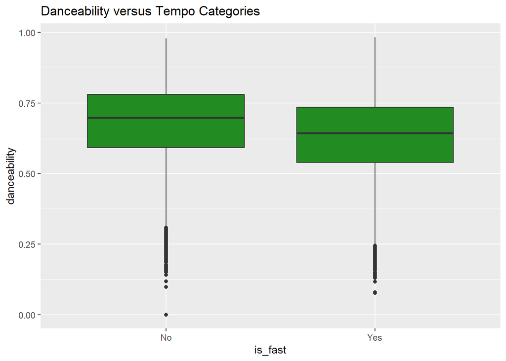

```r
    ## Yes!

# Step 2: Generate box-plots of danceability of the songs stratified by groups:

    spotify_songs %>% ggplot(aes(x=is_fast, y=danceability)) + geom_boxplot(fill="forest green") + labs(title="Danceability versus Tempo Categories")
```

Surprisingly, slower songs tend to be more danceable on average.

# Part 2: Convert nontidy data into tidy data

## 1. Select only unique distinct rows from the dataset based on the track_name and track_artist columns (Hint check out the distinct() function in dplyr).

```r
distinct_songs <- spotify_songs %>% distinct(track_name, track_artist, .keep_all = TRUE)
```

## 2. Add a new column called year_released listing just the year that the song was released. (Hint check out the ymd() function in lubridate R package. Also, if you get a warning message with “failed to parse”, check out the truncated argument in the ymd() function.).

```r
distinct_songs$track_album_release_date <- ymd(distinct_songs$track_album_release_date, truncated = 2)


distinct_songs <- distinct_songs %>% mutate(year_released = year(distinct_songs$track_album_release_date))
```

## 3. Keep only songs that were released in or after 1980.

```r
after1980 <- distinct_songs %>% filter(year_released >= 1980)
```

## 4. Add a new column with the duration of the song in minutes

```r
after1980 <- after1980 %>% mutate(duration_min = duration_ms/1000/60)

after1980$duration_min[1:5]
```

```
## [1] 3.245900 2.710000 2.943600 2.818217 3.150867
```

## 5. For each year_released, calculate the mean of at least 6 of the audio features (e.g. danceability, energy, loudness, etc), or descriptors (e.g. tempo, duration in minutes, etc). (Hint: If all has gone well thus far, you should have a dataset with 41 rows and 7 columns).

```r
after1980 <- after1980 %>% group_by(year_released) %>% summarize(danceability = mean(danceability), energy = mean(energy), valence = mean(valence), speechiness = mean(speechiness),acousticness = mean(acousticness), liveness = mean(liveness))

after1980
```

```
## # A tibble: 41 x 7
##    year_released danceability energy valence speechiness acousticness liveness
##            <dbl>        <dbl>  <dbl>   <dbl>       <dbl>        <dbl>    <dbl>
##  1          1980        0.563  0.711   0.633      0.0611        0.192    0.198
##  2          1981        0.570  0.697   0.665      0.0530        0.164    0.192
##  3          1982        0.652  0.655   0.627      0.0576        0.164    0.173
##  4          1983        0.605  0.734   0.635      0.0527        0.119    0.187
##  5          1984        0.585  0.707   0.617      0.0445        0.194    0.194
##  6          1985        0.609  0.659   0.610      0.0451        0.225    0.165
##  7          1986        0.623  0.665   0.661      0.0473        0.174    0.156
##  8          1987        0.602  0.722   0.623      0.0623        0.142    0.184
##  9          1988        0.672  0.650   0.634      0.0775        0.133    0.165
## 10          1989        0.643  0.700   0.653      0.0627        0.136    0.180
## # ... with 31 more rows
```

## 6.Convert this wide dataset into a long dataset with a new feature and mean_score column

```r
after1980 <- after1980 %>% pivot_longer(-year_released, names_to = "feature", values_to = "mean_score")

after1980
```

```
## # A tibble: 246 x 3
##    year_released feature      mean_score
##            <dbl> <chr>             <dbl>
##  1          1980 danceability     0.563
##  2          1980 energy           0.711
##  3          1980 valence          0.633
##  4          1980 speechiness      0.0611
##  5          1980 acousticness     0.192
##  6          1980 liveness         0.198
##  7          1981 danceability     0.570
##  8          1981 energy           0.697
##  9          1981 valence          0.665
## 10          1981 speechiness      0.0530
## # ... with 236 more rows
```

# Part 3: Data Visualization

Use the functions in ggplot2 package to make a scatter plot of the six (or more) mean_scores (y-axis) over time (x-axis). For full credit, your plot should include:

1. An overall title for the plot and a subtitle summarizing key trends that you found. Also include a caption in the figure with your name.
2. Both the observed points for the mean_score, but also a smoothed non-linear pattern of the trend
3. All six (or more) plots should be shown in the one figure
4. There should be an informative x-axis and y-axis label

Consider playing around with the theme() function to make the figure shine, including playing with background colors, font, etc.

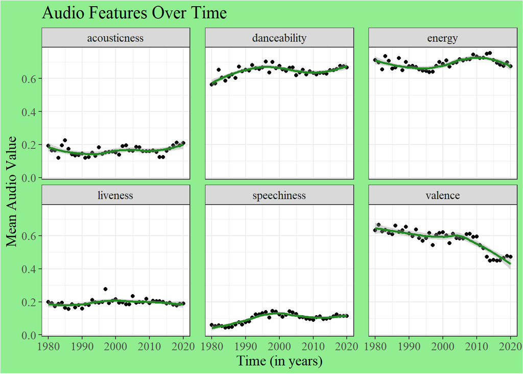

plotify

```r
plotify <- after1980 %>% ggplot(aes(year_released, y = mean_score))

plotify + geom_point() +
    geom_smooth(method = "loess", color= "forest green") +
    facet_wrap(~feature) +
    labs(x = "Time (in years)", y = "Mean Audio Value", title="Audio Features Over Time") +
    theme_bw() +
    theme(panel.spacing.x = unit(1, "lines")) +
    theme(text=element_text(family="serif", size = 14)) +
    theme(plot.background = element_rect("light green"))
```

# Part 4: Make the worst plot you can!

I want you to explore your creative side and make a really awful data visualization in every way. :)

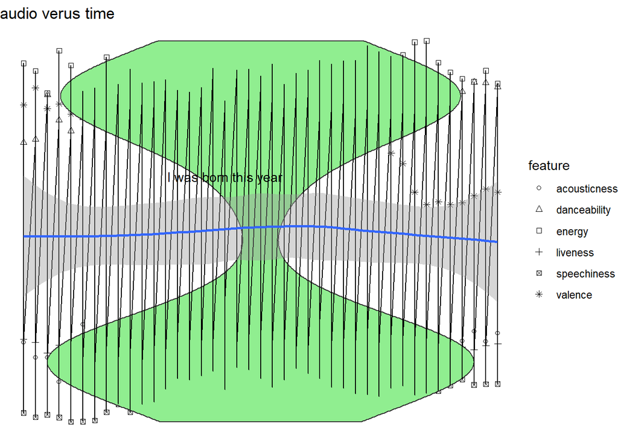

blahtify

```r
blahtify <- after1980 %>% ggplot(aes(year_released, y = mean_score))

blahtify + geom_point(aes(shape = feature)) +
    scale_shape(solid = FALSE) +
    stat_ydensity(kernel = "gaussian", fill="light green") +
    geom_path() +
    theme_void() +
    labs(title="audio verus time") +
    annotate(geom = "text", x = 1997, y = 0.5, label = "I was born this year") +
    geom_smooth()
```

In your document, write 1 - 2 sentences about each different customization you added (using bullets – i.e. there should be at least 7 bullet points each with 1-2 sentences), and how it could be useful for you when you want to make an awesome data visualization.

- I customized each different feature and made the shapes transparent. This customization may be useful if I was interested in making my scatterplots more informative of a third variable.
- `stat_ydensity()`may be useful on its own if I was interested in visualizing the spread of data. For instance, I work with DNA methylation data, and this customization could be useful to see how methylated a site tends to be at baseline across a sample.
- `geom_path()` allowed me to connect the points by a line, which may be a useful customization if you were building a network of interactions.
- `theme_void()` got rid of the axes and tick marks, which could be useful if you were building shapes or 3D contours where the axes do not matter as much or add clutter to the information of interest.
- I added a vague title, but obviously the `labs` geom is very useful for adding textual information to figures when th description is better.
- I used `annotate()` to label an arbitrarily where my birthday is, but it could be used in better ways to label points of interest. For example, you could label an outlier with its participant ID number if you were considering removing it.
- `geom_smooth()` does not show us anything very important in this particular figure, since we are plotting all features together in one figure. However, it could be more informative if we were interested in viewing the mean y values across x’s.

# Part 5. Make my plot better

1. You need to customize it in at least 7 ways to make it better.

```r
# Make a binary variable for track popularity for background
    mean(spotify_songs$track_popularity)
```

```
## [1] 42.47708
```

```r
    genres %>% summarize(mean(track_popularity))
```

```
## # A tibble: 6 x 2
##   playlist_genre `mean(track_popularity)`
##   <chr>                             <dbl>
## 1 edm                                34.8
## 2 latin                              47.0
## 3 pop                                47.7
## 4 r&b                                41.2
## 5 rap                                43.2
## 6 rock                               41.7
```

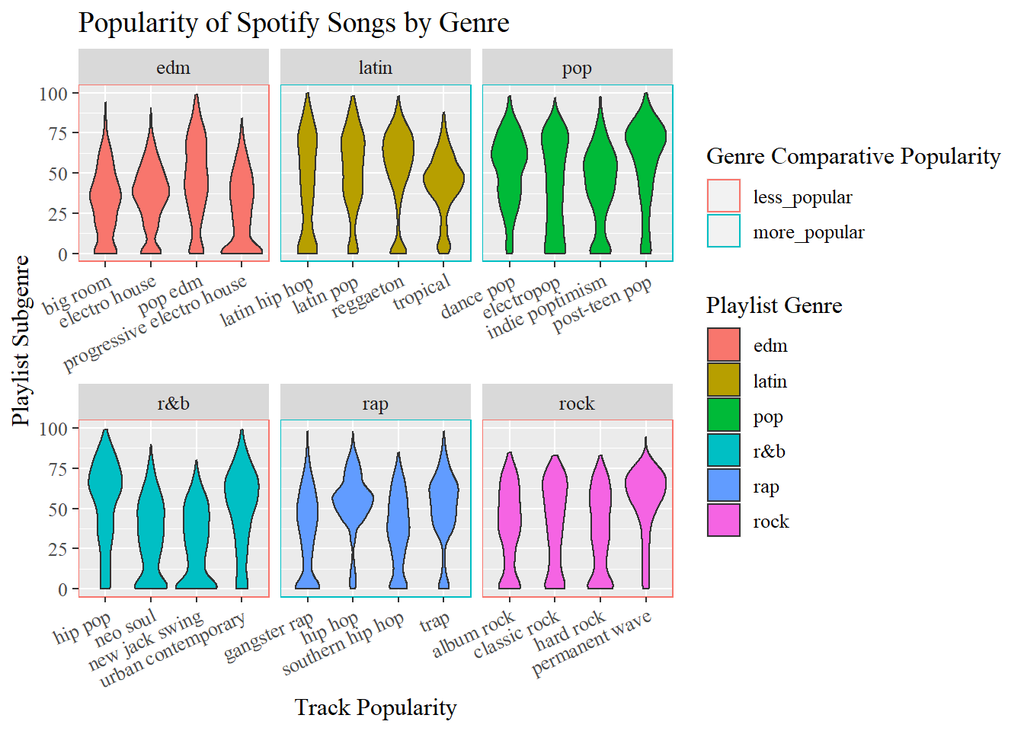

```r
    spotify_songs <- spotify_songs %>% mutate(genre_popularity = if_else(playlist_genre %in% c("latin","pop","rap"), "more_popular", "less_popular"))


## Develop plot

spotify_songs %>%
    ggplot(aes(y=track_popularity, x=playlist_subgenre, fill = playlist_genre)) +
    geom_rect(aes(col = genre_popularity), fill="white", xmin = -Inf, ymin = -Inf, xmax=Inf, ymax=Inf, alpha = 0) +
    geom_violin() +
    facet_wrap( ~ playlist_genre, scales = "free_x") +
    guides(x = guide_axis(angle = 25)) +
    theme(text=element_text(family="serif", size = 12)) +
    labs(x="Track Popularity", y = "Playlist Subgenre") +
    scale_fill_discrete(name = "Playlist Genre") +
    scale_color_discrete(name = "Genre Comparative Popularity") +
    labs(title="Popularity of Spotify Songs by Genre")
```

2. In your document, write 1 - 2 sentences about each different customization you added (using bullets – i.e. there should be at least 7 bullet points each with 1-2 sentences), describing how you improved it.
- First, I calculated which genres had average popularity ratings above the mean value for the whole dataset. I added `geom_rect()` to outline the facets with a color code that corresponds to genre popularity.
- I rotated the x labels using `guides()` function to make them more readable.
- I also modified the font to make the rotated labels easier to read.
- I changed the axis labels to so that the variables were more proper English than how they originally appeared as variables in the data-set.
- I changed the fill legend title.
- I changed the color legend title. Keeping the legends separate is the main reason why I decided to use the ‘color’ function in ggplot for the genre popularity variable instead of ‘fill’.
- I added a title to the plot to describe what data is being portrayed.